# Practica_Viz

Lic. Andres Peñas Ballesteros

Lic. Carla Padilla Franzotti

Mg. Agustín Baricalla

Ing. Juan Félix Orlowski

2024-02-02

## Base R Graphics

Funciones gráficas básicas que están integradas directamente en el lenguaje R y no requieren la instalación de ninguna librería adicional. Funciones

plot() hist() barplot() boxplot() heatmap()

## Ejemplo 1) Diagrama de dispersión

```r
#Variables a graficar:
x <- c(2.2, 3, 3.8, 4.5, 7, 8.5, 6.7, 5.5)
y <- c(4, 5.5, 4.5, 9, 11, 15.2, 13.3, 10.5)
```

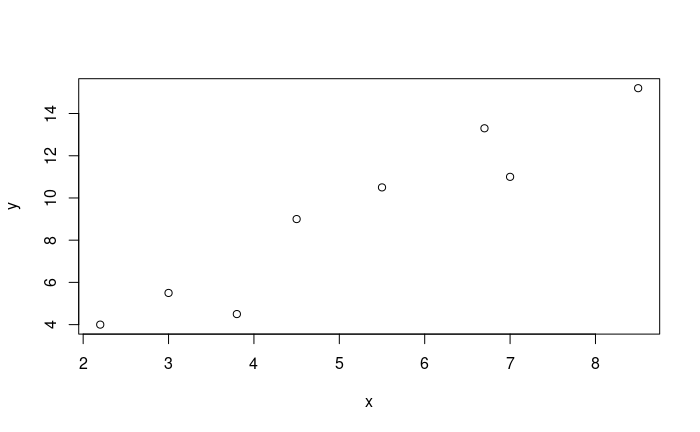

```r
#Graficar los puntos
plot(x, y)
```

# Argumentos

main: título sub: subtítulo xlab o ylab: nombre de los ejes xlim o ylim: rango de los ejes col: color de los bordes lty: tipo de líneas lwd: ancho de líneas alpha: transparencia

## Ejemplo 2) Diagrama de dispersión - Primeras Variaciones

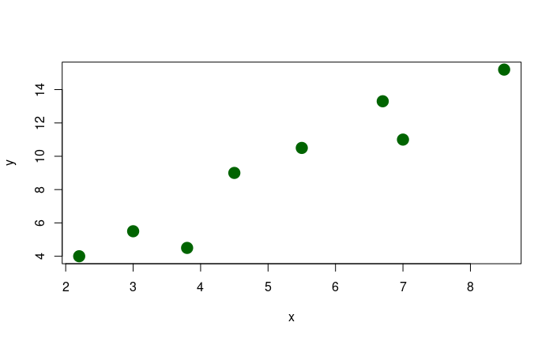

```r
plot(x, y,                  #Datos
pch=19,                  #Símbolo
col="darkgreen",    #Color Símbolo
cex=2)                     #Tamaño Símbolo
```

## Ejemplo 3) Barplot - Variaciones

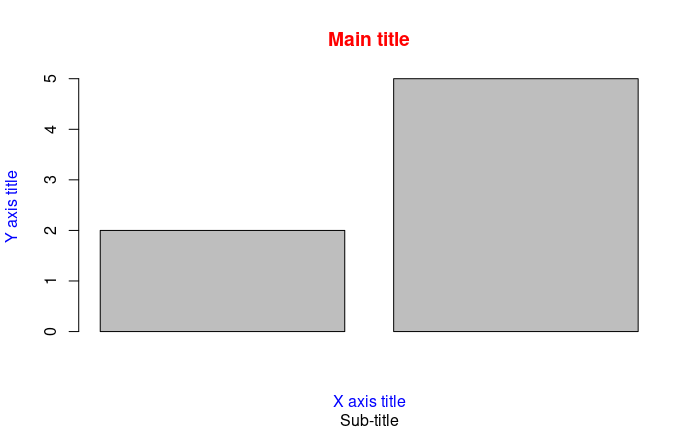

```r
datos <- c(2,5)
barplot(datos,     # c(2,5)
 main="Main title",
        xlab="X axis title",
        ylab="Y axis title",
        sub="Sub-title",
        col.main="red",
 col.lab="blue",
 col.sub="black")
```

## Ejemplo 4) Boxplot - Variaciones

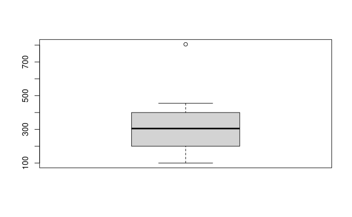

```r
data = c(100, 250, 305, 805, 400, 150, 200, 455, 342)

data <- c(100, 250, 305, 805, 400, 150, 200, 455, 342)


boxplot(data)
```

```r
NA
NA
```

## Ejemplo 5) Histograma

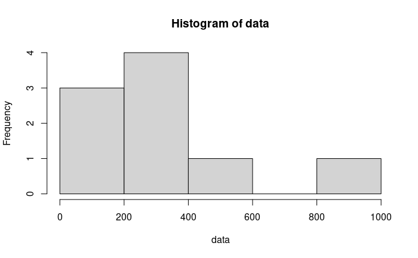

```r
hist(data)
```

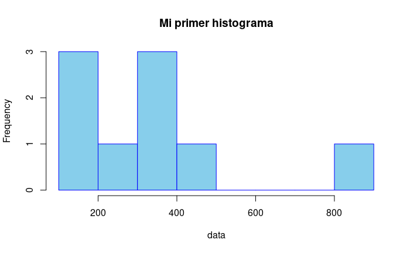

```r
hist(data,
breaks = 10, col= "skyblue",
border = "blue",
main= "Mi primer histograma")
```

## ggplot2

# Los gráficos están compuestos por:

-Datos: información que se desea visualizar. -Mapeo: descripción de cómo se asignan las variables de los datos a atributos estéticos.

Componentes de Mapeo

- Capa (Layer) Colección de elementos geométricos y transformaciones estadísticas. Elementos geométricos (geoms) representan lo que se ve en el gráfico: puntos, líneas, polígonos, etc. Transformaciones estadísticas (stats) resumen los datos, como agrupar y contar observaciones para crear un histograma o ajustar un modelo lineal.
- Escalas (Scales) Mapean valores en el espacio de datos a valores en el espacio estético (color, forma o tamaño). Incluyen la leyenda y los ejes, facilitando la lectura de los valores originales desde el gráfico (mapeo inverso).
- Coordenadas (Coord) Describen cómo se asignan las coordenadas de los datos al plano gráfico. Proporcionan ejes y líneas de cuadrícula para facilitar la lectura del gráfico. Usualmente se utiliza el sistema de coordenadas cartesianas, pero hay otras opciones como coordenadas polares y proyecciones de mapas.
- Faceta (Facet) Especifica cómo dividir y mostrar subconjuntos de datos como múltiples gráficos pequeños (condicionamiento o latticing/trellising).
- Tema (Theme) Controla detalles de visualización, como tamaño de fuente y color de fondo. ggplot2 tiene valores predeterminados cuidadosamente seleccionados.